# airline_sentiment_2

## Mniej przetworzony dataset

Struktura tego pliku jest taka sama jak tego z pierwszej części. Jedyną różnicą jest sposób przetworzenia datasetu, na którym testowane będą klasyfikatory.

Zmiany w preprocessingu w stosunku do "poprawnie" opracowanego datasetu z części pierwszej:

- wiersze zawierające wartości NaN zostały zastąpione zerami (w pierwszej części zostały one usunięte)
- dane nie zostały poddane normalizacji ani standaryzacji

```python
from sklearnex import patch_sklearn
patch_sklearn()
import pandas as pd
import numpy as np
import matplotlib.pyplot as plt
import torch
import torch.nn as nn
from torch.utils.data import DataLoader, TensorDataset
from sklearn.model_selection import train_test_split, RandomizedSearchCV
from sklearn import tree
from sklearn.neighbors import KNeighborsClassifier
from sklearn.naive_bayes import GaussianNB
from sklearn.ensemble import RandomForestClassifier
from sklearn.metrics import confusion_matrix, ConfusionMatrixDisplay
import copy
from scipy.stats import randint
```

```
Intel(R) Extension for Scikit-learn* enabled (https://github.com/intel/scikit-learn-intelex)
```

```python
df_train = pd.read_csv('train.csv')
df_test = pd.read_csv('test.csv')
df = pd.concat([df_train, df_test], ignore_index=True)
pd.options.display.max_rows = 30
```

## Eksploracja zbioru danych

```python
df.shape
```

```
(129880, 25)
```

```python
df.head()
```

|  | Unnamed: 0 | id | Gender | Customer Type | Age | Type of Travel | Class | Flight Distance | Inflight wifi service | Departure/Arrival time convenient | ... | Inflight entertainment | On-board service | Leg room service | Baggage handling | Checkin service | Inflight service | Cleanliness | Departure Delay in Minutes | Arrival Delay in Minutes | satisfaction |
| --- | --- | --- | --- | --- | --- | --- | --- | --- | --- | --- | --- | --- | --- | --- | --- | --- | --- | --- | --- | --- | --- |
| 0 | 0 | 70172 | Male | Loyal Customer | 13 | Personal Travel | Eco Plus | 460 | 3 | 4 | ... | 5 | 4 | 3 | 4 | 4 | 5 | 5 | 25 | 18.0 | neutral or dissatisfied |
| 1 | 1 | 5047 | Male | disloyal Customer | 25 | Business travel | Business | 235 | 3 | 2 | ... | 1 | 1 | 5 | 3 | 1 | 4 | 1 | 1 | 6.0 | neutral or dissatisfied |
| 2 | 2 | 110028 | Female | Loyal Customer | 26 | Business travel | Business | 1142 | 2 | 2 | ... | 5 | 4 | 3 | 4 | 4 | 4 | 5 | 0 | 0.0 | satisfied |
| 3 | 3 | 24026 | Female | Loyal Customer | 25 | Business travel | Business | 562 | 2 | 5 | ... | 2 | 2 | 5 | 3 | 1 | 4 | 2 | 11 | 9.0 | neutral or dissatisfied |
| 4 | 4 | 119299 | Male | Loyal Customer | 61 | Business travel | Business | 214 | 3 | 3 | ... | 3 | 3 | 4 | 4 | 3 | 3 | 3 | 0 | 0.0 | satisfied |

5 rows × 25 columns

```python
df.tail()
```

|  | Unnamed: 0 | id | Gender | Customer Type | Age | Type of Travel | Class | Flight Distance | Inflight wifi service | Departure/Arrival time convenient | ... | Inflight entertainment | On-board service | Leg room service | Baggage handling | Checkin service | Inflight service | Cleanliness | Departure Delay in Minutes | Arrival Delay in Minutes | satisfaction |
| --- | --- | --- | --- | --- | --- | --- | --- | --- | --- | --- | --- | --- | --- | --- | --- | --- | --- | --- | --- | --- | --- |
| 129875 | 25971 | 78463 | Male | disloyal Customer | 34 | Business travel | Business | 526 | 3 | 3 | ... | 4 | 3 | 2 | 4 | 4 | 5 | 4 | 0 | 0.0 | neutral or dissatisfied |
| 129876 | 25972 | 71167 | Male | Loyal Customer | 23 | Business travel | Business | 646 | 4 | 4 | ... | 4 | 4 | 5 | 5 | 5 | 5 | 4 | 0 | 0.0 | satisfied |
| 129877 | 25973 | 37675 | Female | Loyal Customer | 17 | Personal Travel | Eco | 828 | 2 | 5 | ... | 2 | 4 | 3 | 4 | 5 | 4 | 2 | 0 | 0.0 | neutral or dissatisfied |
| 129878 | 25974 | 90086 | Male | Loyal Customer | 14 | Business travel | Business | 1127 | 3 | 3 | ... | 4 | 3 | 2 | 5 | 4 | 5 | 4 | 0 | 0.0 | satisfied |
| 129879 | 25975 | 34799 | Female | Loyal Customer | 42 | Personal Travel | Eco | 264 | 2 | 5 | ... | 1 | 1 | 2 | 1 | 1 | 1 | 1 | 0 | 0.0 | neutral or dissatisfied |

5 rows × 25 columns

```python
df.info()
```

```
<class 'pandas.core.frame.DataFrame'>
RangeIndex: 129880 entries, 0 to 129879
Data columns (total 25 columns):
 #   Column                             Non-Null Count   Dtype
---  ------                             --------------   -----
 0   Unnamed: 0                         129880 non-null  int64
 1   id                                 129880 non-null  int64
 2   Gender                             129880 non-null  object
 3   Customer Type                      129880 non-null  object
 4   Age                                129880 non-null  int64
 5   Type of Travel                     129880 non-null  object
 6   Class                              129880 non-null  object
 7   Flight Distance                    129880 non-null  int64
 8   Inflight wifi service              129880 non-null  int64
 9   Departure/Arrival time convenient  129880 non-null  int64
```

[output cut: 17 more lines]

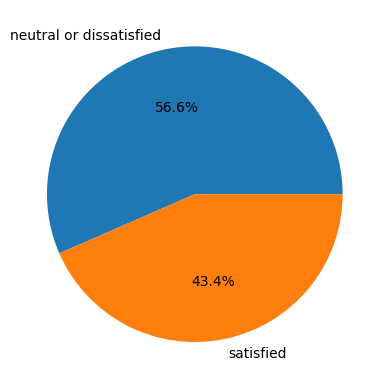

```python
plt.pie(df['satisfaction'].value_counts(), labels=df['satisfaction'].value_counts().index, autopct='%1.1f%%');
```

```python
df.isnull().sum()
```

```
Unnamed: 0                             0
id                                     0
Gender                                 0
Customer Type                          0
Age                                    0
Type of Travel                         0
Class                                  0
Flight Distance                        0
Inflight wifi service                  0
Departure/Arrival time convenient      0
Ease of Online booking                 0
Gate location                          0
Food and drink                         0
Online boarding                        0
Seat comfort                           0
Inflight entertainment                 0
On-board service                       0
Leg room service                       0
Baggage handling                       0
Checkin service                        0
Inflight service                       0
Cleanliness                            0
Departure Delay in Minutes             0
Arrival Delay in Minutes             393
satisfaction                           0
dtype: int64
```

```python
# find not numerical data
df.select_dtypes(exclude=['float64', 'int64'])
```

|  | Gender | Customer Type | Type of Travel | Class | satisfaction |
| --- | --- | --- | --- | --- | --- |
| 0 | Male | Loyal Customer | Personal Travel | Eco Plus | neutral or dissatisfied |
| 1 | Male | disloyal Customer | Business travel | Business | neutral or dissatisfied |
| 2 | Female | Loyal Customer | Business travel | Business | satisfied |
| 3 | Female | Loyal Customer | Business travel | Business | neutral or dissatisfied |
| 4 | Male | Loyal Customer | Business travel | Business | satisfied |
| ... | ... | ... | ... | ... | ... |
| 129875 | Male | disloyal Customer | Business travel | Business | neutral or dissatisfied |
| 129876 | Male | Loyal Customer | Business travel | Business | satisfied |
| 129877 | Female | Loyal Customer | Personal Travel | Eco | neutral or dissatisfied |
| 129878 | Male | Loyal Customer | Business travel | Business | satisfied |
| 129879 | Female | Loyal Customer | Personal Travel | Eco | neutral or dissatisfied |

129880 rows × 5 columns

```python
df['Arrival Delay in Minutes']
```

```
0         18.0
1          6.0
2          0.0
3          9.0
4          0.0
          ...
129875     0.0
129876     0.0
129877     0.0
129878     0.0
129879     0.0
Name: Arrival Delay in Minutes, Length: 129880, dtype: float64
```

### Data preprocessing

```python
df['Arrival Delay in Minutes'] = df['Arrival Delay in Minutes'].fillna(0) # fill nan with 0
df.drop(columns=['Unnamed: 0', 'id'], inplace=True) # delete columns with no information
df['Arrival Delay in Minutes'] = df['Arrival Delay in Minutes'].astype('int64') # convert float to int
```

```python
# one hot encoding for categorical variables
df_num = pd.get_dummies(df, columns=df.select_dtypes(exclude=['float64', 'int64']).columns.to_list(), drop_first=True, dtype='int64')
```

```python
df_num.info()
```

```
<class 'pandas.core.frame.DataFrame'>
RangeIndex: 129880 entries, 0 to 129879
Data columns (total 24 columns):
 #   Column                             Non-Null Count   Dtype
---  ------                             --------------   -----
 0   Age                                129880 non-null  int64
 1   Flight Distance                    129880 non-null  int64
 2   Inflight wifi service              129880 non-null  int64
 3   Departure/Arrival time convenient  129880 non-null  int64
 4   Ease of Online booking             129880 non-null  int64
 5   Gate location                      129880 non-null  int64
 6   Food and drink                     129880 non-null  int64
 7   Online boarding                    129880 non-null  int64
 8   Seat comfort                       129880 non-null  int64
 9   Inflight entertainment             129880 non-null  int64
```

[output cut: 16 more lines]

```python
# number of unique values for each column
for c in df_num.columns:
    print(c, df_num[c].nunique())
```

```
Age 75
Flight Distance 3821
Inflight wifi service 6
Departure/Arrival time convenient 6
Ease of Online booking 6
Gate location 6
Food and drink 6
Online boarding 6
Seat comfort 6
Inflight entertainment 6
On-board service 6
Leg room service 6
Baggage handling 5
Checkin service 6
Inflight service 6
Cleanliness 6
Departure Delay in Minutes 466
Arrival Delay in Minutes 472
Gender_Male 2
Customer Type_disloyal Customer 2
Type of Travel_Personal Travel 2
Class_Eco 2
Class_Eco Plus 2
satisfaction_satisfied 2
```

```python
df_num.shape
```

```
(129880, 24)
```

```python
# split data into train, dev and test sets
df_train, df_test_and_dev = train_test_split(df_num, test_size=0.3, random_state=42)
df_dev, df_test = train_test_split(df_test_and_dev, test_size=0.5, random_state=42)

# split data into features and labels
X_train, Y_train = df_train.drop(columns=['satisfaction_satisfied']), df_train['satisfaction_satisfied']
X_dev, Y_dev = df_dev.drop(columns=['satisfaction_satisfied']), df_dev['satisfaction_satisfied']
X_test, Y_test = df_test.drop(columns=['satisfaction_satisfied']), df_test['satisfaction_satisfied']
```

## Algorytmy klasyfikujące

### kNN

Algorytm kNN zostanie przetestowany dla następujących wartości k:

- 2
- 4
- 6
- 8
- 10
- 12

```
Neighbors: 2
Dev Set Accuracy: 72.43%
Test Set Accuracy: 73.13%
```

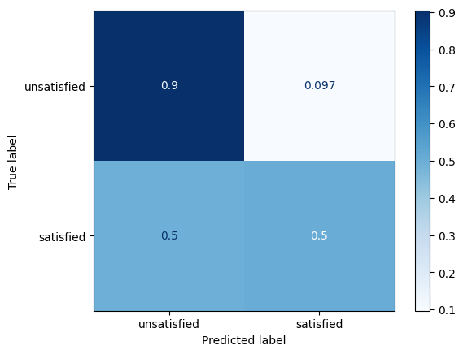

```
Neighbors: 4
Dev Set Accuracy: 73.80%
Test Set Accuracy: 74.49%
```

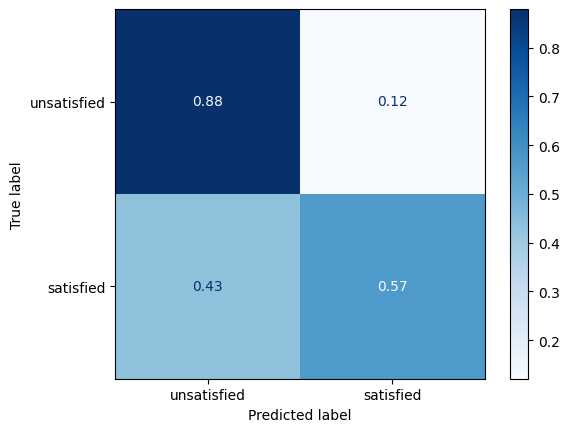

```
Neighbors: 6
Dev Set Accuracy: 74.23%
Test Set Accuracy: 74.69%
```

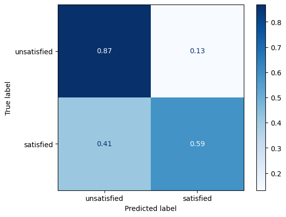

```
Neighbors: 8
Dev Set Accuracy: 74.29%
Test Set Accuracy: 74.80%
```

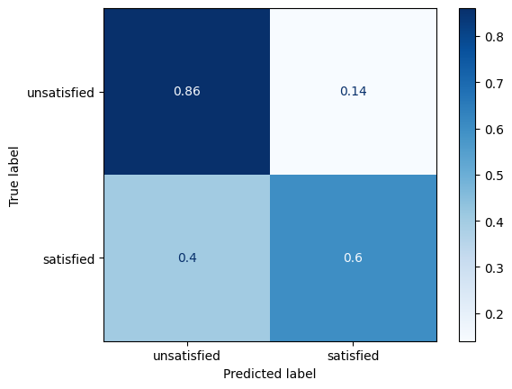

```
Neighbors: 10
Dev Set Accuracy: 74.53%
Test Set Accuracy: 74.62%
```

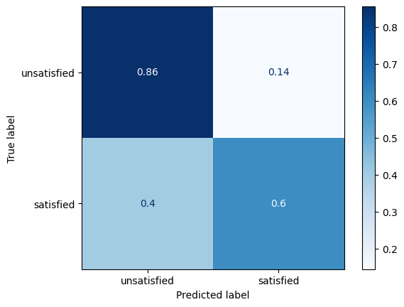

```
Neighbors: 12
Dev Set Accuracy: 74.49%
Test Set Accuracy: 74.34%
```

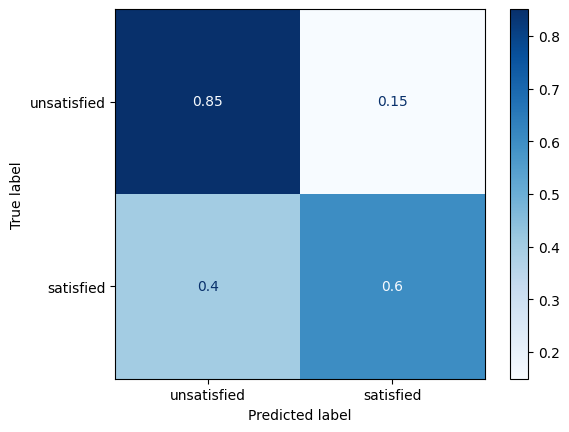

```python
dev_acc_arr, test_acc_arr = [], []
for n_neighbors in range(2, 13, 2):
    knn_clf = KNeighborsClassifier(n_neighbors=n_neighbors, metric='euclidean')
    knn_clf.fit(X_train, Y_train)
    y_pred = knn_clf.predict(X_test)
    print(f"Neighbors: {n_neighbors}")
    dev_acc = knn_clf.score(X_dev, Y_dev)
    test_acc = knn_clf.score(X_test, Y_test)
    dev_acc_arr.append(dev_acc)
    test_acc_arr.append(test_acc)

    print(f"Dev Set Accuracy: {dev_acc*100:.2f}%")
    print(f"Test Set Accuracy: {test_acc*100:.2f}%")
    ConfusionMatrixDisplay.from_estimator(knn_clf, X_test, Y_test, cmap=plt.cm.Blues, display_labels=['unsatisfied','satisfied'], normalize='true');
    plt.show()
```

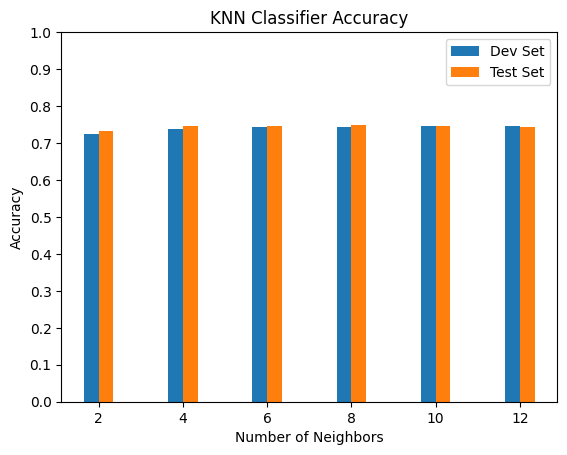

```python
x = np.arange(2, 13, 2)
width = 0.35

plt.bar(x - width/2, dev_acc_arr, width=width, label='Dev Set')
plt.bar(x + width/2, test_acc_arr, width=width, label='Test Set')
plt.xlabel('Number of Neighbors')
plt.ylabel('Accuracy')

plt.xticks(x)
plt.title('KNN Classifier Accuracy')
plt.yticks(np.arange(0.0, 1.1, 0.1))
plt.legend();
```

Dla parametru k większwgo niż 4 nie można zaobserwować zwiększania się dokładności klasyfikatora. Utrzymuje się on na poziomie około 74.5%.

### Decision Tree

Drzewo decyzyjne zostało zaimplementowane w dwóch wariantach:

- większym, bez przycinania gałęzi
- mniejszym, z przycinaniem gałęzi (maksymalna wysokość drzewa została ustawiona na 15 poziomów)

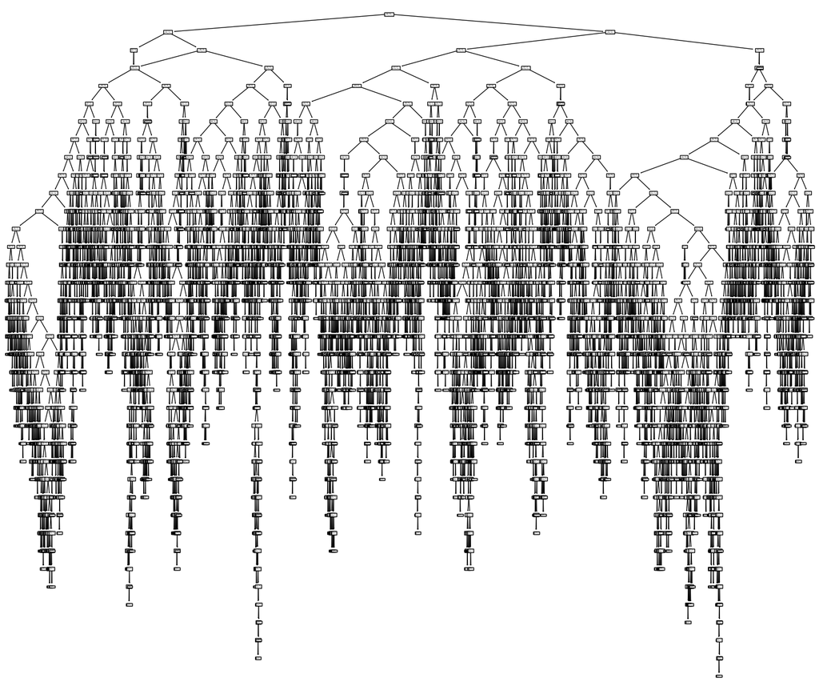

```python
# drzewo bez przycinania
tree_clf = tree.DecisionTreeClassifier()
tree_clf = tree_clf.fit(X_train, Y_train)
plt.figure(figsize=(20, 17))
tree.plot_tree(tree_clf);
```

```
Test Set Accuracy: 94.37%
Dev Set Accuracy: 94.37%
```

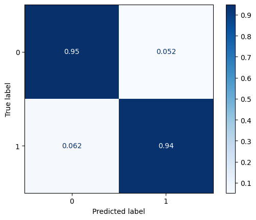

```python
print(f"Test Set Accuracy: {tree_clf.score(X_test, Y_test)*100:.2f}%")
print(f"Dev Set Accuracy: {tree_clf.score(X_dev, Y_dev)*100:.2f}%")
ConfusionMatrixDisplay.from_estimator(tree_clf, X_test, Y_test, cmap=plt.cm.Blues, normalize='true');
```

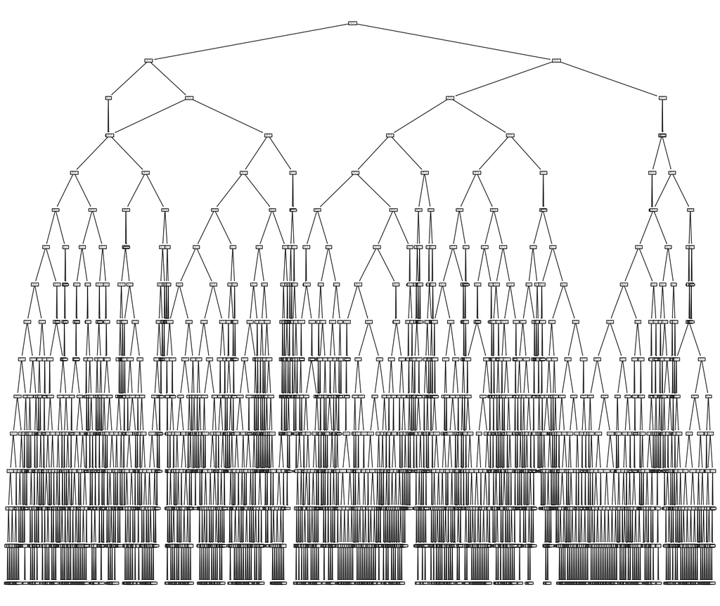

```python
# drzewo z przycinaniem
tree_clf_trimmed = tree.DecisionTreeClassifier(max_depth=15)
tree_clf_trimmed = tree_clf_trimmed.fit(X_train, Y_train)
plt.figure(figsize=(20, 17))
tree.plot_tree(tree_clf_trimmed);
```

```
Test Set Accuracy: 95.16%
Dev Set Accuracy: 95.02%
```

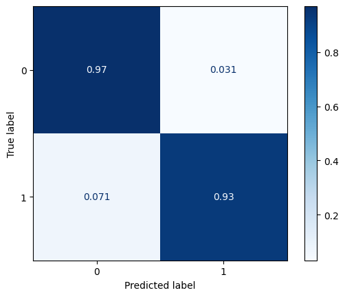

```python
print(f"Test Set Accuracy: {tree_clf_trimmed.score(X_test, Y_test)*100:.2f}%")
print(f"Dev Set Accuracy: {tree_clf_trimmed.score(X_dev, Y_dev)*100:.2f}%")
ConfusionMatrixDisplay.from_estimator(tree_clf_trimmed, X_test, Y_test, cmap=plt.cm.Blues, normalize='true');
```

Trochę większą dokładność na zbiorze testowym dało drzewo w wariancie z przycinananiem gałęzi. Jednocześnie czas wykonywania się tego algorytmu był krótszy niż w przypadku drzewa decyzyjnego bez przycinania gałęzi.

### Random Forest

```
Test Set Accuracy: 95.65%
Dev Set Accuracy: 95.50%
```

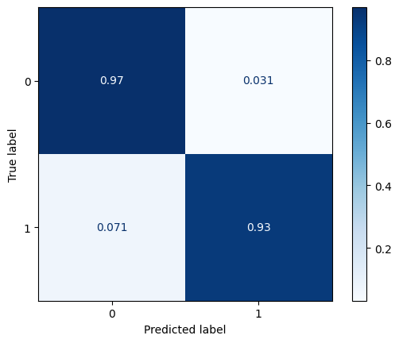

```python
rf = RandomForestClassifier()
param_dist = {'n_estimators': randint(50,500),
              'max_depth': randint(1,15)}

rand_search = RandomizedSearchCV(rf,
                                 param_distributions = param_dist,
                                 n_iter=10,
                                 cv=5)

rand_search.fit(X_train, Y_train)

print(f"Test Set Accuracy: {rand_search.score(X_test, Y_test)*100:.2f}%")
print(f"Dev Set Accuracy: {rand_search.score(X_dev, Y_dev)*100:.2f}%")
ConfusionMatrixDisplay.from_estimator(tree_clf_trimmed, X_test, Y_test, cmap=plt.cm.Blues, normalize='true');
```

### Naive Bayes

```
Dev Set Accuracy: 86.15%
Test Set Accuracy: 85.71%
```

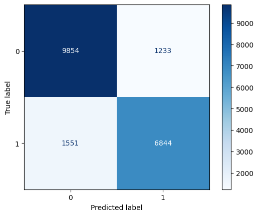

```python
gnb = GaussianNB()
gnb.fit(X_train, Y_train)
print(f"Dev Set Accuracy: {gnb.score(X_dev, Y_dev)*100:.2f}%")
print(f"Test Set Accuracy: {gnb.score(X_test, Y_test)*100:.2f}%")
ConfusionMatrixDisplay.from_estimator(gnb, X_test, Y_test, cmap=plt.cm.Blues);
```

### MLP

```python
device = torch.device('cuda' if torch.cuda.is_available() else 'cpu')

X_train = torch.tensor(X_train.to_numpy(), dtype=torch.float32).to(device)
X_dev = torch.tensor(X_dev.to_numpy(), dtype=torch.float32).to(device)
X_test = torch.tensor(X_test.to_numpy(), dtype=torch.float32).to(device)

Y_train = torch.tensor(Y_train.to_numpy(), dtype=torch.float32).to(device).view(-1, 1)
Y_dev = torch.tensor(Y_dev.to_numpy(), dtype=torch.float32).to(device).view(-1, 1)
Y_test = torch.tensor(Y_test.to_numpy(), dtype=torch.float32).to(device).view(-1, 1)

train_loader = DataLoader(TensorDataset(X_train, Y_train), batch_size=32, shuffle=True)
```

```python
n_hidden = 16
inp_size = X_train.shape[1]

class MLP1(nn.Module):
    def __init__(self, inp_size, n_hidden):
        super().__init__()
        self.linear_tanh_stack = nn.Sequential(
        nn.Linear(inp_size, 2*n_hidden, bias=True), nn.LayerNorm(2*n_hidden), nn.Tanh(),
        nn.Linear(2*n_hidden, n_hidden, bias=True), nn.LayerNorm(n_hidden), nn.Tanh(),
        nn.Linear(n_hidden, n_hidden, bias=True), nn.LayerNorm(n_hidden), nn.Tanh(),
        nn.Linear(n_hidden, n_hidden, bias=True), nn.LayerNorm(n_hidden), nn.Tanh(),
        nn.Linear(n_hidden, 1)
    )

    def forward(self, x):
        logits = self.linear_tanh_stack(x)
        return logits


class MLP2(nn.Module):
    def __init__(self, inp_size, n_hidden):
        super().__init__()
        self.linear_tanh_stack = nn.Sequential(
        nn.Linear(inp_size, 2*n_hidden, bias=False), nn.BatchNorm1d(2*n_hidden), nn.Tanh(),
        nn.Linear(2*n_hidden, n_hidden, bias=False), nn.BatchNorm1d(n_hidden), nn.Tanh(),
        nn.Linear(n_hidden, n_hidden, bias=False), nn.BatchNorm1d(n_hidden), nn.Tanh(),
        nn.Linear(n_hidden, n_hidden, bias=False), nn.BatchNorm1d(n_hidden), nn.Tanh(),
        nn.Linear(n_hidden, 1)
    )

    def forward(self, x):
        logits = self.linear_tanh_stack(x)
        return logits


class MLP3(nn.Module):
    def __init__(self, inp_size, n_hidden):
        super().__init__()
        self.linear_tanh_stack = nn.Sequential(
        nn.Linear(inp_size, 2*n_hidden, bias=False), nn.BatchNorm1d(2*n_hidden), nn.ReLU(),
        nn.Linear(2*n_hidden, n_hidden, bias=False), nn.BatchNorm1d(n_hidden), nn.ReLU(),
        nn.Linear(n_hidden, n_hidden, bias=False), nn.BatchNorm1d(n_hidden), nn.ReLU(),
        nn.Linear(n_hidden, n_hidden, bias=False), nn.BatchNorm1d(n_hidden), nn.ReLU(),
        nn.Linear(n_hidden, 1)
    )

    def forward(self, x):
        logits = self.linear_tanh_stack(x)
        return logits


class MLP4(nn.Module):
    def __init__(self, inp_size, n_hidden):
        super().__init__()
        self.linear_tanh_stack = nn.Sequential(
        nn.Linear(inp_size, 2*n_hidden, bias=True), nn.LayerNorm(2*n_hidden), nn.ReLU(),
        nn.Linear(2*n_hidden, n_hidden, bias=True), nn.LayerNorm(n_hidden), nn.ReLU(),
        nn.Linear(n_hidden, n_hidden, bias=True), nn.LayerNorm(n_hidden), nn.ReLU(),
        nn.Linear(n_hidden, n_hidden, bias=True), nn.LayerNorm(n_hidden), nn.ReLU(),
        nn.Linear(n_hidden, 1)
    )

    def forward(self, x):
        logits = self.linear_tanh_stack(x)
        return logits


class MLP5(nn.Module):
    def __init__(self, inp_size, n_hidden):
        super().__init__()
        self.linear_tanh_stack = nn.Sequential(
        nn.Linear(inp_size, 2*n_hidden, bias=False), nn.BatchNorm1d(2*n_hidden), nn.ReLU(),
        nn.Linear(2*n_hidden, n_hidden, bias=False), nn.BatchNorm1d(n_hidden), nn.ReLU(),
        nn.Linear(n_hidden, n_hidden, bias=False), nn.BatchNorm1d(n_hidden), nn.ReLU(),
        nn.Linear(n_hidden, n_hidden, bias=False), nn.BatchNorm1d(n_hidden), nn.ReLU(),
        nn.Linear(n_hidden, n_hidden, bias=False), nn.BatchNorm1d(n_hidden), nn.ReLU(),
        nn.Linear(n_hidden, n_hidden, bias=False), nn.BatchNorm1d(n_hidden), nn.ReLU(),
        nn.Linear(n_hidden, 1)
    )

    def forward(self, x):
        logits = self.linear_tanh_stack(x)
        return logits


model_1 = MLP1(inp_size, n_hidden).to(device)
model_2 = MLP2(inp_size, n_hidden).to(device)
model_3 = MLP3(inp_size, n_hidden).to(device)
model_4 = MLP4(inp_size, n_hidden).to(device)
model_5 = MLP5(inp_size, n_hidden).to(device)

models = [model_1, model_2, model_3, model_4, model_5]
models_copy = [copy.deepcopy(model) for model in models]
```

```python
@torch.no_grad()
def get_accuracy(model, set_str):
    model.eval()
    X, Y = {'dev set': [X_dev, Y_dev],
            'test set': [X_test, Y_test],
            'train set': [X_train, Y_train]}[set_str]
    Y_pred = model(X)
    Y_pred = torch.sigmoid(Y_pred)
    Y_pred = torch.round(Y_pred)
    acc = round((Y_pred == Y).sum().item() / len(Y), 4) * 100
    return acc
```

```python
@torch.no_grad()
def print_confusion_matrix(model):
    model.eval()
    X, Y = X_test, Y_test
    Y_pred = model(X)
    Y_pred = torch.sigmoid(Y_pred)
    Y_pred = torch.round(Y_pred)
    cm = confusion_matrix(Y_pred.cpu().numpy(), Y.cpu().numpy())
    dips = ConfusionMatrixDisplay(cm, display_labels=['unsatisfied','satisfied'])
    dips.plot()
```

```python
def training_loop(model, epochs, i, optim):

    criterion = nn.BCEWithLogitsLoss()
    optimizer = torch.optim.Adam(model.parameters()) if optim == 'Adam' else torch.optim.SGD(model.parameters(), lr=0.001, weight_decay=0.001)

    train_acc_arr, dev_acc_arr = [], []
    train_acc_arr.append(get_accuracy(model, 'train set'))
    dev_acc_arr.append(get_accuracy(model, 'dev set'))
    for epoch in range(epochs):
        model.train()
        for x, y in train_loader:

            out = model(x)
            loss = criterion(out, y)

            optimizer.zero_grad()

            loss.backward()

            optimizer.step()

        # stats
        train_acc_arr.append(get_accuracy(model, 'train set'))
        dev_acc_arr.append(get_accuracy(model, 'dev set'))

    print(f'Test set accuracy of Model{i} and {optim} optimizer: {get_accuracy(model, "test set"):.2f}%')
    print_confusion_matrix(model)
    plt.show()
    plt.plot(range(1, len(train_acc_arr)+1), train_acc_arr, label='train acc')
    plt.plot(range(1, len(dev_acc_arr)+1), dev_acc_arr, label='dev acc')
    plt.yticks(np.arange(0, 110, 10), np.arange(0, 110, 10))
    plt.title(f'Model{i}, {optim} optimizer')
    plt.xlabel('Epochs')
    plt.ylabel('Accuracy')
    plt.legend();
    plt.show()
```

```
Test set accuracy of Model1 and Adam optimizer: 91.29%
```

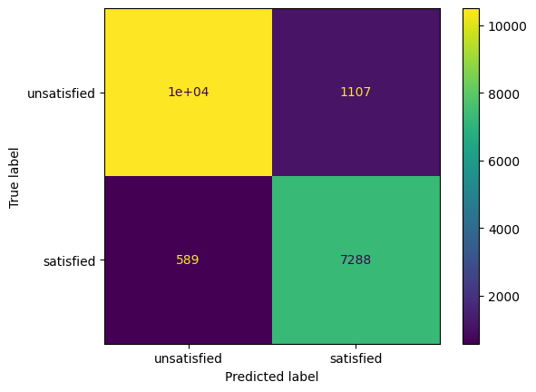

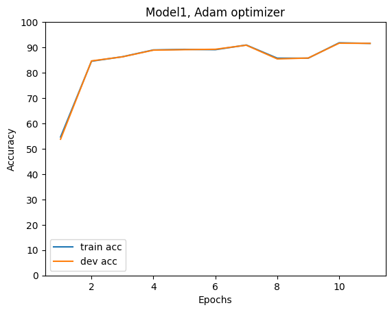

```
Test set accuracy of Model1 and SGD optimizer: 61.56%
```

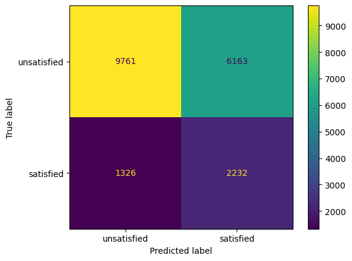

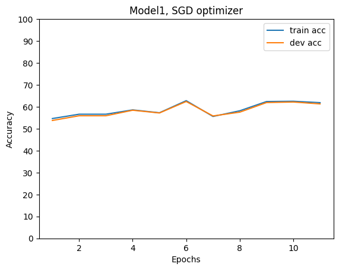

```
Test set accuracy of Model2 and Adam optimizer: 90.80%
```

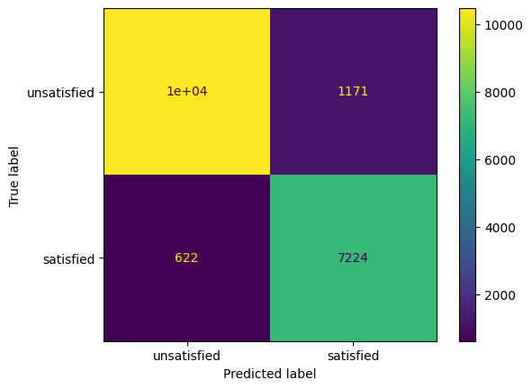

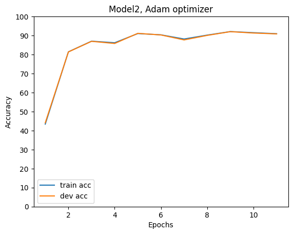

```
Test set accuracy of Model2 and SGD optimizer: 62.41%
```

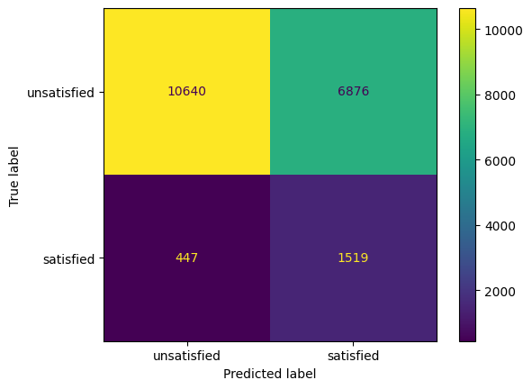

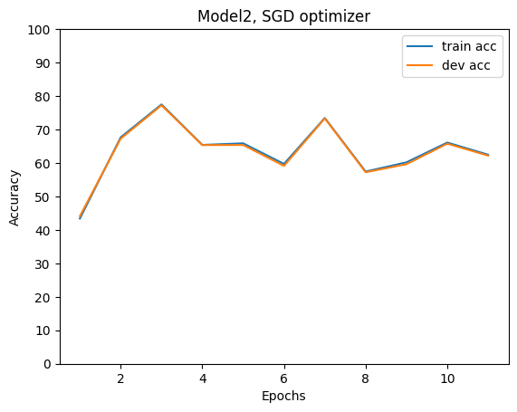

```
Test set accuracy of Model3 and Adam optimizer: 87.51%
```

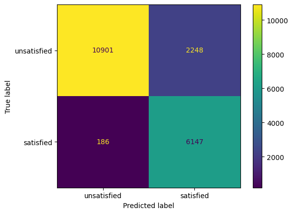

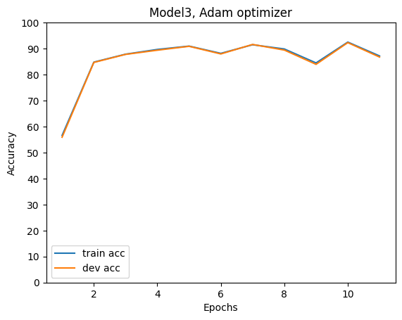

```
Test set accuracy of Model3 and SGD optimizer: 73.06%
```

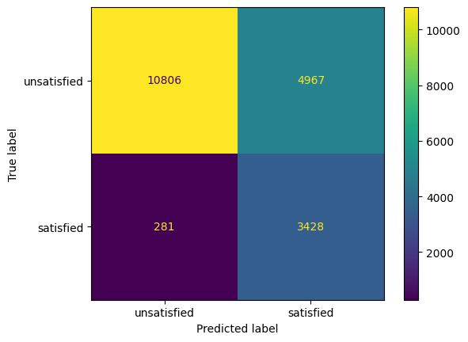

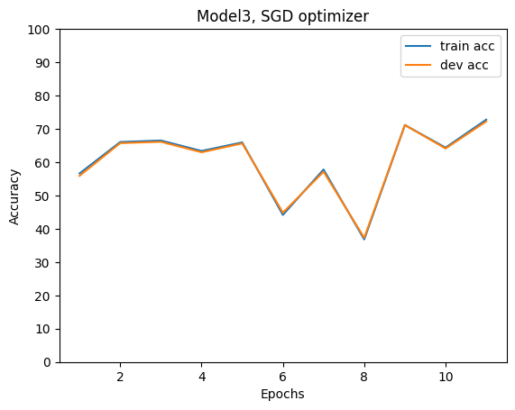

```
Test set accuracy of Model4 and Adam optimizer: 91.54%
```

[8 more figures not shown]

```python
for i in range(len(models)):
    for optim in ['Adam', 'SGD']:
        if optim == 'Adam':
            training_loop(models[i], 10, i+1, optim)
        else:
            training_loop(models_copy[i], 10, i+1, optim)
```

Sieci neuronowe z optymalizatorem SGD dały zdecydowanie gorsze wyniki niż te z optymalizatorem Adam.

## Podsumowanie wyników

Dla klasyfikatorów testowanych w kilku wariantach (np. kNN z kilkoma wartościami k) do porównania został wybrany najlepszy wynik.

|  | Random Forest | Drzewo decyzyjne | Naiwny Bayes | kNN | Sieć neuronowa |
| --- | --- | --- | --- | --- | --- |
| Dokładność | 95.7% | 95.2% | 85.7% | 74.8% | 92% |

Klasyfikatorem o najwyższej skuteczności okazał się Random Forest.

Klasyfikatorem o najniższej skuteczności okazał się algorytm kNN.

### Porównanie z bardziej przetworzonym datasetem

Klasyfikatory, których dokładność spadła w porównaniu z lepiej przetworzonym datasetem:

- kNN
- sieć neuronowa

Klasyfikatory, których dokładność nie zmieniłą się w porównaniu z lepiej przetworzonym datasetem (różnica wyniosła mniej niż 1 p.proc.):

- Random Forest
- Drzewo Decyzyjne
- Naiwny Bayes

Wynika z tego, że algorytm kNN i sieci neuronowa gorzej radzą sobie z nieznormalizowanymi danymi. W szczególności algorytm kNN poradził sobie dużo gorzej (17.4 p.proc. różnicy).

Ponadto, można było zaobserwować, że czas wykonywania się algorytmów w mnie przetworzonym zbiorze danych był trochę dłuższy (prawdopodobnie efekt braku normalizacji).

#### Bibliografia

https://www.datacamp.com/tutorial/random-forests-classifier-python  
https://scikit-learn.org/stable/supervised_learning.html#supervised-learning  
https://pytorch.org/docs/stable/index.html  
https://www.kaggle.com/datasets/teejmahal20/airline-passenger-satisfaction